# Using gs.engine(): Genstat Socket Engine

Yuxiao Wang

2025-05-15

# Overview

This vignette demonstrates how to use the gs.engine function provided by the gsengine package to run Genstat code chunks from within an R Markdown document.

It assumes a Genstat server is already running and accessible over a socket connection.

# Setting up the connection

You can configure the Genstat server host and port via environment variables:

```r
Sys.setenv(GENSTAT_HOST = "localhost")
Sys.setenv(GENSTAT_PORT = "8085")
```

Alternatively, you can pass them directly to ‘gs.engine()’:

```r
knitr::knit_engines$set(gs = gsengine::gs.engine(host = "localhost", port = 8085))
```

# Writing Genstat chunks

To **run Genstat code** in your R Markdown file, specify the chunk engine as ‘gs’:

Example:

```
VARIATE [VALUES=1,2,3] Foo
```

```
PRINT Foo
```

```
     Foo
   1.000
   2.000
   3.000
```

This code will be sent to the Genstat server, and any output will be captured and rendered in the final document.

# Warning and Table Formatting

The ‘gs.engine’ will automatically:

1. **Highlight Genstat warnings/Faults** in red.
2. **Format complex tables** (like factors/variates) as Markdown tables.
3. **Format simple tables** (like value/rank summaries) as well-structured Markdown tables.
4. **Recognize and format structural markers** in Genstat output for better readability: -Section breaks such as 1., 2., or 3.1 are rendered as Markdown section dividers:—

-Headings indicated by === (equal signs under a line) will be converted into bold headings.

-Subheadings indicated by — (hyphens under a line) will be converted into italicized subheadings.

Example:

```
FOR Sheet = 'Trial A1','Trial A2','Trial A3','Trial A4'
    IMPORT '%DATA%/WheatTrials.xlsx'; SHEET=Sheet; ISAVE=pData
    FOR Y = Mean_Population_m2,Harvest_Moisture,Yield_14%_t_ha_adj
        TREATMENTS Cultivar
        BLOCKS Rep
        ANOVA [FPROB=yes; PSE=LSD] Y
        AMCOMPARISON Cultivar
    ENDFOR
ENDFOR
```

*Loading Spreadsheet File*

Catalogue of file WheatTrials.xlsx

Sheet Title: Trial A1 Description: Data read from D:.xlsx [Trial A1]A2:N53 Sheet Type: vector Index Type Nval Name

| Index | Type | Nval | Name |
| --- | --- | --- | --- |
| 1 | factor | 52 | Entry |
| 2 | factor | 52 | Plot |
| 3 | factor | 52 | Row |
| 4 | factor | 52 | Column |
| 5 | factor | 52 | Block |
| 6 | factor | 52 | Rep |
| 7 | factor | 52 | Cultivar |
| 8 | variate | 52 | Mean_Population_m2 |
| 9 | variate | 52 | Plot_Size_m2 |
| 10 | variate | 52 | Plot_Yield_kg |
| 11 | variate | 52 | Harvest_Moisture |
| 12 | variate | 52 | Yield_14%_t_ha_adj |

**Analysis of variance**

Variate: Mean_Population_m2

Source of variation d.f. s.s. m.s. v.r. F pr.

Rep stratum 3 344.2 114.7 0.40

Rep.*Units* stratum Cultivar 12 4354.8 362.9 1.26 0.283 Residual 36 10368.3 288.0

Total 51 15067.3

- MESSAGE: the following units have large residuals.

Rep 3 *units* 8 34.5 s.e. 14.1

**Tables of means**

Variate: Mean_Population_m2

Grand mean 192.9

Cultivar Blaze CAW722 Encore Envy Excess Flame Monarch 200.0 191.2 211.2 196.2 191.2 187.5 198.8

Cultivar Nelson Resolve Sirus Victor Wanaka WWT1695 181.2 183.8 183.8 181.2 195.0 206.2

*Least significant differences of means (5% level)*

Table Cultivar rep. 4 d.f. 36 l.s.d. 24.34

**Fisher’s protected least significant difference test**

*Cultivar*

******** Warning 129, code UF 2, statement 242 in procedure AMCOMPARISON Fisher’s protected LSD is not calculated as variance ratio for Cultivar is not significant.

**Analysis of variance**

Variate: Harvest_Moisture

Source of variation d.f. s.s. m.s. v.r. F pr.

Rep stratum 3 0.2113 0.0704 0.68

Rep.*Units* stratum Cultivar 12 7.6969 0.6414 6.20 <.001 Residual 36 3.7262 0.1035

Total 51 11.6344

- MESSAGE: the following units have large residuals.

Rep 1 *units* 12 0.6 s.e. 0.3 Rep 2 *units* 2 0.6 s.e. 0.3

**Tables of means**

Variate: Harvest_Moisture

Grand mean 15.5

Cultivar Blaze CAW722 Encore Envy Excess Flame Monarch 15.0 15.2 15.1 14.9 15.5 16.0 16.1

Cultivar Nelson Resolve Sirus Victor Wanaka WWT1695 15.1 15.6 15.6 15.8 16.0 15.2

*Least significant differences of means (5% level)*

Table Cultivar rep. 4 d.f. 36 l.s.d. 0.46

**Fisher’s protected least significant difference test**

*Cultivar*

```
           Mean
```

| Item | Value | Rank |
| --- | --- | --- |
| Blaze | 15.02 | ab |
| Nelson | 15.10 | ab |
| Encore | 15.15 | abc |
| CAW722 | 15.22 | abcd |
| WWT1695 | 15.25 | abcd |
| Excess | 15.47 | bcde |
| Sirus | 15.57 | cdef |
| Resolve | 15.62 | defg |
| Victor | 15.77 | efg |
| Flame | 16.02 | fg |
| Wanaka | 16.02 | fg |
| Monarch | 16.07 | g |

**Analysis of variance**

Variate: Yield_14%_t_ha_adj

Source of variation d.f. s.s. m.s. v.r. F pr.

Rep stratum 3 8.2134 2.7378 4.27

Rep.*Units* stratum Cultivar 12 35.2689 2.9391 4.58 <.001 Residual 36 23.1068 0.6419

Total 51 66.5891

- MESSAGE: the following units have large residuals.

Rep 1 *units* 2 -1.79 s.e. 0.67

**Tables of means**

Variate: Yield_14%_t_ha_adj

Grand mean 12.45

Cultivar Blaze CAW722 Encore Envy Excess Flame Monarch 12.23 13.46 12.42 14.04 10.60 12.62 12.70

Cultivar Nelson Resolve Sirus Victor Wanaka WWT1695 12.75 12.50 11.32 12.29 12.07 12.85

*Least significant differences of means (5% level)*

Table Cultivar rep. 4 d.f. 36 l.s.d. 1.149

**Fisher’s protected least significant difference test**

*Cultivar*

```
           Mean
```

| Item | Value | Rank |
| --- | --- | --- |
| Excess | 10.60 | a |
| Sirus | 11.32 | ab |
| Wanaka | 12.07 | bc |
| Blaze | 12.23 | bc |
| Victor | 12.29 | bc |
| Encore | 12.42 | bcd |
| Resolve | 12.50 | cd |
| Flame | 12.62 | cd |
| Monarch | 12.70 | cd |
| Nelson | 12.75 | cd |
| WWT1695 | 12.85 | cd |
| CAW722 | 13.46 | de |
| Envy | 14.04 | e |

*Loading Spreadsheet File*

Catalogue of file WheatTrials.xlsx

Sheet Title: Trial A2 Description: Data read from D:.xlsx [Trial A2]A2:M65 Sheet Type: vector Index Type Nval Name

| Index | Type | Nval | Name |
| --- | --- | --- | --- |
| 1 | factor | 64 | Entry |
| 2 | factor | 64 | Plot |
| 3 | factor | 64 | Row |
| 4 | factor | 64 | Column |
| 5 | factor | 64 | Block |
| 6 | factor | 64 | Rep |
| 7 | factor | 64 | Cultivar |
| 8 | variate | 64 | Mean_Population_m2 |
| 9 | variate | 64 | Plot_Size_m2 |
| 10 | variate | 64 | Plot_Yield_kg |
| 11 | variate | 64 | Harvest_Moisture |
| 12 | variate | 64 | Yield_14%_t_ha_adj |

**Analysis of variance**

Variate: Mean_Population_m2

Source of variation d.f. s.s. m.s. v.r. F pr.

Rep stratum 3 943.1 314.4 2.11

Rep.*Units* stratum Cultivar 15 7998.6 533.2 3.57 <.001 Residual 45 6713.9 149.2

Total 63 15655.6

- MESSAGE: the following units have large residuals.

Rep 2 *units* 2 26. s.e. 10.

**Tables of means**

Variate: Mean_Population_m2

Grand mean 139.

Cultivar Blaze Brilliant CAW722 CAW733 Encore Envy Excess 113. 137. 154. 149. 140. 122. 139.

Cultivar Flame Monarch Nelson Resolve Sirus Victor Wanaka 139. 129. 146. 126. 143. 142. 140.

Cultivar WHT951 WWT1695 158. 141.

*Least significant differences of means (5% level)*

Table Cultivar rep. 4 d.f. 45 l.s.d. 17.4

**Fisher’s protected least significant difference test**

*Cultivar*

```
             Mean
```

| Item | Value | Rank |
| --- | --- | --- |
| Blaze | 113.3 | a |
| Envy | 122.1 | ab |
| Resolve | 126.3 | abc |
| Monarch | 129.2 | abcd |
| Brilliant | 136.7 | bcde |
| Excess | 139.2 | bcdef |
| Flame | 139.2 | bcdef |
| Wanaka | 140.0 | cdef |
| Encore | 140.4 | cdef |
| WWT1695 | 140.8 | cdef |
| Victor | 142.1 | cdefg |
| Sirus | 142.9 | cdefg |
| Nelson | 146.3 | defg |
| CAW733 | 149.2 | efg |
| CAW722 | 154.2 | fg |
| WHT951 | 158.3 | g |

**Analysis of variance**

Variate: Harvest_Moisture

Source of variation d.f. s.s. m.s. v.r. F pr.

Rep stratum 3 0.26547 0.08849 4.70

Rep.*Units* stratum Cultivar 15 6.08859 0.40591 21.56 <.001 Residual 45 0.84703 0.01882

Total 63 7.20109

- MESSAGE: the following units have large residuals.

Rep 1 *units* 2 -0.4 s.e. 0.1 Rep 2 *units* 15 -0.3 s.e. 0.1

**Tables of means**

Variate: Harvest_Moisture

Grand mean 13.5

Cultivar Blaze Brilliant CAW722 CAW733 Encore Envy Excess 13.3 13.1 13.3 13.8 13.6 13.4 13.5

Cultivar Flame Monarch Nelson Resolve Sirus Victor Wanaka 13.6 13.2 13.3 13.5 13.2 13.4 14.5

Cultivar WHT951 WWT1695 13.4 13.7

*Least significant differences of means (5% level)*

Table Cultivar rep. 4 d.f. 45 l.s.d. 0.20

**Fisher’s protected least significant difference test**

*Cultivar*

```
             Mean
```

| Item | Value | Rank |
| --- | --- | --- |
| Brilliant | 13.13 | a |
| Monarch | 13.15 | ab |
| Sirus | 13.23 | abc |
| CAW722 | 13.25 | abcd |
| Nelson | 13.30 | abcde |
| Blaze | 13.33 | bcde |
| Victor | 13.35 | cde |
| Envy | 13.38 | cdef |
| WHT951 | 13.43 | def |
| Resolve | 13.45 | ef |
| Excess | 13.48 | ef |
| Encore | 13.55 | fg |
| Flame | 13.55 | fg |
| WWT1695 | 13.73 | gh |
| CAW733 | 13.75 | h |
| Wanaka | 14.45 | i |

**Analysis of variance**

Variate: Yield_14%_t_ha_adj

Source of variation d.f. s.s. m.s. v.r. F pr.

Rep stratum 3 0.31345 0.10448 2.05

Rep.*Units* stratum Cultivar 15 9.56350 0.63757 12.52 <.001 Residual 45 2.29135 0.05092

Total 63 12.16831

**Tables of means**

Variate: Yield_14%_t_ha_adj

Grand mean 10.70

Cultivar Blaze Brilliant CAW722 CAW733 Encore Envy Excess 10.73 10.28 11.05 11.29 10.46 10.60 10.68

Cultivar Flame Monarch Nelson Resolve Sirus Victor Wanaka 10.55 10.90 10.62 10.00 10.40 10.62 10.35

Cultivar WHT951 WWT1695 11.44 11.29

*Least significant differences of means (5% level)*

Table Cultivar rep. 4 d.f. 45 l.s.d. 0.321

**Fisher’s protected least significant difference test**

*Cultivar*

```
             Mean
```

| Item | Value | Rank |
| --- | --- | --- |
| Resolve | 10.00 | a |
| Brilliant | 10.28 | ab |
| Wanaka | 10.35 | bc |
| Sirus | 10.40 | bcd |
| Encore | 10.46 | bcde |
| Flame | 10.55 | bcde |
| Envy | 10.60 | bcdef |
| Victor | 10.62 | cdef |
| Nelson | 10.62 | cdef |
| Excess | 10.68 | def |
| Blaze | 10.73 | efg |
| Monarch | 10.90 | fg |
| CAW722 | 11.05 | gh |
| CAW733 | 11.29 | hi |
| WWT1695 | 11.29 | hi |
| WHT951 | 11.44 | i |

*Loading Spreadsheet File*

Catalogue of file WheatTrials.xlsx

Sheet Title: Trial A3 Description: Data read from D:.xlsx [Trial A3]A2:Y65 Sheet Type: vector Index Type Nval Name

| Index | Type | Nval | Name |
| --- | --- | --- | --- |
| 1 | factor | 64 | Entry |
| 2 | factor | 64 | Plot |
| 3 | factor | 64 | Row |
| 4 | factor | 64 | Column |
| 5 | factor | 64 | Block |
| 6 | factor | 64 | Rep |
| 7 | factor | 64 | Cultivar |
| 8 | variate | 64 | Mean_Population_m2 |
| 9 | variate | 64 | Plot_Size_m2 |
| 10 | variate | 64 | Plot_Yield_kg |
| 11 | variate | 64 | Harvest_Moisture |
| 12 | variate | 64 | Yield_14%_t_ha_adj |

**Analysis of variance**

Variate: Mean_Population_m2

Source of variation d.f. s.s. m.s. v.r. F pr.

Rep stratum 3 2290.4 763.5 5.64

Rep.*Units* stratum Cultivar 15 10057.2 670.5 4.95 <.001 Residual 45 6093.6 135.4

Total 63 18441.3

**Tables of means**

Variate: Mean_Population_m2

Grand mean 110.

Cultivar Blaze Brilliant CAW722 CAW733 Encore Envy Excess 88. 109. 135. 128. 120. 108. 105.

Cultivar Flame Monarch Nelson Resolve Sirus Victor Wanaka 106. 90. 103. 92. 110. 115. 114.

Cultivar WHT951 WWT1695 115. 122.

*Least significant differences of means (5% level)*

Table Cultivar rep. 4 d.f. 45 l.s.d. 16.6

**Fisher’s protected least significant difference test**

*Cultivar*

```
             Mean
```

| Item | Value | Rank |
| --- | --- | --- |
| Blaze | 87.9 | a |
| Monarch | 90.0 | ab |
| Resolve | 92.1 | abc |
| Nelson | 103.3 | abcd |
| Excess | 104.6 | bcd |
| Flame | 105.8 | bcde |
| Envy | 108.3 | cde |
| Brilliant | 108.8 | de |
| Sirus | 110.0 | de |
| Wanaka | 114.2 | def |
| WHT951 | 115.0 | def |
| Victor | 115.4 | def |
| Encore | 119.6 | defg |
| WWT1695 | 121.7 | efg |
| CAW733 | 127.5 | fg |
| CAW722 | 134.6 | g |

**Analysis of variance**

Variate: Harvest_Moisture

Source of variation d.f. s.s. m.s. v.r. F pr.

Rep stratum 3 0.23047 0.07682 2.06

Rep.*Units* stratum Cultivar 15 5.47109 0.36474 9.79 <.001 Residual 45 1.67703 0.03727

Total 63 7.37859

- MESSAGE: the following units have large residuals.

Rep 4 *units* 1 -0.5 s.e. 0.2

**Tables of means**

Variate: Harvest_Moisture

Grand mean 13.6

Cultivar Blaze Brilliant CAW722 CAW733 Encore Envy Excess 13.6 13.5 13.2 14.1 13.6 13.4 13.6

Cultivar Flame Monarch Nelson Resolve Sirus Victor Wanaka 13.6 13.1 13.6 13.3 13.3 13.5 14.2

Cultivar WHT951 WWT1695 13.4 13.9

*Least significant differences of means (5% level)*

Table Cultivar rep. 4 d.f. 45 l.s.d. 0.27

**Fisher’s protected least significant difference test**

*Cultivar*

```
             Mean
```

| Item | Value | Rank |
| --- | --- | --- |
| Monarch | 13.10 | a |
| CAW722 | 13.20 | ab |
| Resolve | 13.35 | abc |
| Sirus | 13.35 | abc |
| Envy | 13.40 | bc |
| WHT951 | 13.40 | bc |
| Brilliant | 13.45 | bc |
| Victor | 13.50 | c |
| Encore | 13.55 | c |
| Nelson | 13.55 | c |
| Flame | 13.58 | c |
| Blaze | 13.60 | c |
| Excess | 13.60 | c |
| WWT1695 | 13.95 | d |
| CAW733 | 14.05 | de |
| Wanaka | 14.25 | e |

**Analysis of variance**

Variate: Yield_14%_t_ha_adj

Source of variation d.f. s.s. m.s. v.r. F pr.

Rep stratum 3 26.7714 8.9238 73.73

Rep.*Units* stratum Cultivar 15 10.6535 0.7102 5.87 <.001 Residual 45 5.4464 0.1210

Total 63 42.8713

- MESSAGE: the following units have large residuals.

Rep 1 *units* 9 0.67 s.e. 0.29 Rep 3 *units* 6 -0.67 s.e. 0.29

**Tables of means**

Variate: Yield_14%_t_ha_adj

Grand mean 14.45

Cultivar Blaze Brilliant CAW722 CAW733 Encore Envy Excess 14.47 14.23 14.15 14.75 14.26 14.29 13.83

Cultivar Flame Monarch Nelson Resolve Sirus Victor Wanaka 14.14 14.64 13.90 13.94 14.90 15.24 14.75

Cultivar WHT951 WWT1695 15.01 14.68

*Least significant differences of means (5% level)*

Table Cultivar rep. 4 d.f. 45 l.s.d. 0.495

**Fisher’s protected least significant difference test**

*Cultivar*

[output not shown]

*Loading Spreadsheet File*

Catalogue of file WheatTrials.xlsx

Sheet Title: Trial A4 Description: Data read from D:.xlsx [Trial A4]A2:L65 Sheet Type: vector Index Type Nval Name

| Index | Type | Nval | Name |
| --- | --- | --- | --- |
| 1 | factor | 64 | Entry |
| 2 | factor | 64 | Plot |
| 3 | factor | 64 | Row |
| 4 | factor | 64 | Column |
| 5 | factor | 64 | Block |
| 6 | factor | 64 | Rep |
| 7 | factor | 64 | Cultivar |
| 8 | variate | 64 | Mean_Population_m2 |
| 9 | variate | 64 | Plot_Size_m2 |
| 10 | variate | 64 | Plot_Yield_kg |
| 11 | variate | 64 | Harvest_Moisture |
| 12 | variate | 64 | Yield_14%_t_ha_adj |

**Analysis of variance**

Variate: Mean_Population_m2

Source of variation d.f. s.s. m.s. v.r. F pr.

Rep stratum 3 470.6 156.9 1.20

Rep.*Units* stratum Cultivar 15 3480.6 232.0 1.78 0.069 Residual 45 5863.5 130.3

Total 63 9814.7

- MESSAGE: the following units have large residuals.

Rep 1 *units* 1 28. s.e. 10. Rep 2 *units* 7 29. s.e. 10.

**Tables of means**

Variate: Mean_Population_m2

Grand mean 118.

Cultivar Blaze Brilliant CAW722 CAW733 Encore Envy Excess 105. 109. 133. 128. 118. 112. 125.

Cultivar Flame Monarch Nelson Resolve Sirus Victor Wanaka 114. 116. 115. 117. 129. 119. 116.

Cultivar WHT951 WWT1695 115. 113.

*Least significant differences of means (5% level)*

Table Cultivar rep. 4 d.f. 45 l.s.d. 16.3

**Fisher’s protected least significant difference test**

*Cultivar*

******** Warning 130, code UF 2, statement 242 in procedure AMCOMPARISON Fisher’s protected LSD is not calculated as variance ratio for Cultivar is not significant.

**Analysis of variance**

Variate: Harvest_Moisture

Source of variation d.f. s.s. m.s. v.r. F pr.

Rep stratum 3 0.54172 0.18057 2.01

Rep.*Units* stratum Cultivar 15 8.60734 0.57382 6.38 <.001 Residual 45 4.04578 0.08991

Total 63 13.19484

- MESSAGE: the following units have large residuals.

Rep 3 *units* 16 0.6 s.e. 0.3

**Tables of means**

Variate: Harvest_Moisture

Grand mean 18.2

Cultivar Blaze Brilliant CAW722 CAW733 Encore Envy Excess 18.8 18.0 17.9 18.1 18.3 18.1 18.0

Cultivar Flame Monarch Nelson Resolve Sirus Victor Wanaka 18.4 18.0 18.4 18.2 17.3 18.0 19.0

Cultivar WHT951 WWT1695 18.3 18.3

*Least significant differences of means (5% level)*

Table Cultivar rep. 4 d.f. 45 l.s.d. 0.43

**Fisher’s protected least significant difference test**

*Cultivar*

```
             Mean
```

| Item | Value | Rank |
| --- | --- | --- |
| Sirus | 17.28 | a |
| CAW722 | 17.93 | b |
| Brilliant | 17.95 | bc |
| Monarch | 17.98 | bc |
| Excess | 18.00 | bc |
| Victor | 18.00 | bc |
| Envy | 18.05 | bc |
| CAW733 | 18.13 | bc |
| Resolve | 18.20 | bc |
| Encore | 18.25 | bc |
| WHT951 | 18.28 | bc |
| WWT1695 | 18.33 | bc |
| Nelson | 18.35 | bcd |
| Flame | 18.38 | cd |
| Blaze | 18.78 | de |
| Wanaka | 18.98 | e |

**Analysis of variance**

Variate: Yield_14%_t_ha_adj

Source of variation d.f. s.s. m.s. v.r. F pr.

Rep stratum 3 3.6444 1.2148 6.10

Rep.*Units* stratum Cultivar 15 27.7649 1.8510 9.29 <.001 Residual 45 8.9616 0.1991

Total 63 40.3709

**Tables of means**

Variate: Yield_14%_t_ha_adj

Grand mean 11.26

Cultivar Blaze Brilliant CAW722 CAW733 Encore Envy Excess 11.66 10.55 12.02 11.87 11.21 11.76 10.47

Cultivar Flame Monarch Nelson Resolve Sirus Victor Wanaka 10.92 11.29 10.55 10.20 11.45 11.28 10.75

Cultivar WHT951 WWT1695 12.80 11.45

*Least significant differences of means (5% level)*

Table Cultivar rep. 4 d.f. 45 l.s.d. 0.636

**Fisher’s protected least significant difference test**

*Cultivar*

```
             Mean
```

| Item | Value | Rank |
| --- | --- | --- |
| Resolve | 10.20 | a |
| Excess | 10.47 | ab |
| Brilliant | 10.55 | ab |
| Nelson | 10.55 | ab |
| Wanaka | 10.75 | abc |
| Flame | 10.92 | bcd |
| Encore | 11.21 | cde |
| Victor | 11.28 | cdef |
| Monarch | 11.29 | cdef |
| WWT1695 | 11.45 | defg |
| Sirus | 11.45 | defg |
| Blaze | 11.66 | efg |
| Envy | 11.76 | efg |
| CAW733 | 11.87 | fg |
| CAW722 | 12.02 | g |
| WHT951 | 12.80 | h |

You can enable **table storage** by setting options in the chunk header:

{gs, format_complex_tables=TRUE, format_simple_tables=TRUE}

-Tables will be available as lists in global variables:

1. complex_tables_all_chunks
2. simple_tables_all_chunks

Example:

```r
complex_tables_all_chunks
```

```
#> [[1]]
#> [[1]][[1]]
#>    Index    Type Nval               Name
#> 1      1  factor   52              Entry
#> 2      2  factor   52               Plot
#> 3      3  factor   52                Row
#> 4      4  factor   52             Column
#> 5      5  factor   52              Block
#> 6      6  factor   52                Rep
#> 7      7  factor   52           Cultivar
#> 8      8 variate   52 Mean_Population_m2
#> 9      9 variate   52       Plot_Size_m2
#> 10    10 variate   52      Plot_Yield_kg
#> 11    11 variate   52   Harvest_Moisture
#> 12    12 variate   52 Yield_14%_t_ha_adj
#>
#>
#> [[2]]
#> [[2]][[1]]
#>    Index    Type Nval               Name
#> 1      1  factor   64              Entry
#> 2      2  factor   64               Plot
#> 3      3  factor   64                Row
#> 4      4  factor   64             Column
#> 5      5  factor   64              Block
#> 6      6  factor   64                Rep
#> 7      7  factor   64           Cultivar
#> 8      8 variate   64 Mean_Population_m2
#> 9      9 variate   64       Plot_Size_m2
#> 10    10 variate   64      Plot_Yield_kg
#> 11    11 variate   64   Harvest_Moisture
#> 12    12 variate   64 Yield_14%_t_ha_adj
#>
#>
#> [[3]]
#> list()
#>
#> [[4]]
#> [[4]][[1]]
#>    Index    Type Nval               Name
```

[output cut: 21 more lines]

```
#> 2      2  factor   64               Plot
#> 3      3  factor   64                Row
#> 4      4  factor   64             Column
#> 5      5  factor   64              Block
#> 6      6  factor   64                Rep
#> 7      7  factor   64           Cultivar
#> 8      8 variate   64 Mean_Population_m2
#> 9      9 variate   64       Plot_Size_m2
#> 10    10 variate   64      Plot_Yield_kg
#> 11    11 variate   64   Harvest_Moisture
#> 12    12 variate   64 Yield_14%_t_ha_adj
#>
#>
#> [[7]]
#> list()
```

```r
simple_tables_all_chunks
```

```
#> [[1]]
#> list()
#>
#> [[2]]
#> [[2]][[1]]
#>       Item Value Rank
#> 1    Blaze 15.02   ab
#> 2   Nelson 15.10   ab
#> 3   Encore 15.15  abc
#> 4   CAW722 15.22 abcd
#> 5  WWT1695 15.25 abcd
#> 6   Excess 15.47 bcde
#> 7    Sirus 15.57 cdef
#> 8  Resolve 15.62 defg
#> 9   Victor 15.77  efg
```

[output cut: 163 more lines]

# Displaying Genstat Graphics

If Genstat outputs a **PNG image**, it will be displayed directly in the output document. These images are saved locally with filenames like ‘img_1.png’, ‘img_2.png’, etc.

Example:

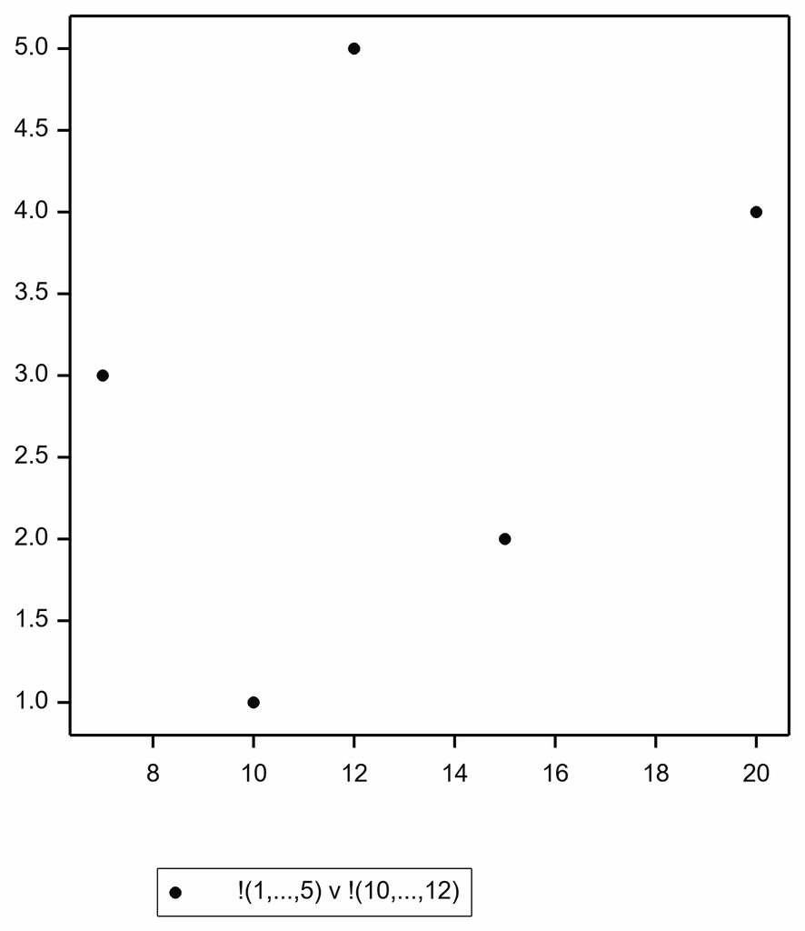

```
DGRAPH !(1,2,3,4,5); !(10,15,7,20,12)
```

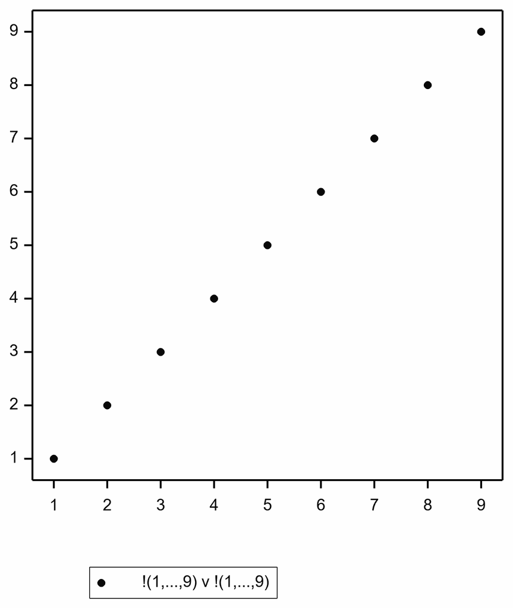

```
DGRAPH !(1...9); !(1...9)
```

# Echo-only Code Blocks

1. If you want to display the Genstat code **without evaluating** it:

{gs, eval=FALSE}

Example:

```
PRINT 'This should not run.'
```

2. By default, the ‘gs.engine’ **does** show the Genstat commands submitted in each chunk.

To **hide Genstat code lines** in the rendered output, use the ‘echo = FALSE’ option in the chunk header:

{gs, echo=FALSE}

Example:

*Loading Spreadsheet File*

Catalogue of file WheatTrials.xlsx

Sheet Title: Trial A1 Description: Data read from D:.xlsx [Trial A1]A2:N53 Sheet Type: vector Index Type Nval Name

| Index | Type | Nval | Name |
| --- | --- | --- | --- |
| 1 | factor | 52 | Entry |
| 2 | factor | 52 | Plot |
| 3 | factor | 52 | Row |
| 4 | factor | 52 | Column |
| 5 | factor | 52 | Block |
| 6 | factor | 52 | Rep |
| 7 | factor | 52 | Cultivar |
| 8 | variate | 52 | Mean_Population_m2 |
| 9 | variate | 52 | Plot_Size_m2 |
| 10 | variate | 52 | Plot_Yield_kg |
| 11 | variate | 52 | Harvest_Moisture |
| 12 | variate | 52 | Yield_14%_t_ha_adj |

This will only include the Genstat result or tables in the final document output.

# Troubleshooting

If you experience connection issues:

1. Ensure your Genstat socket server is running and listening on the correct port.
2. Test using ‘telnet ’ or similar tools.

```r
#devtools::build_rmd("vignettes/gsengine.Rmd")
#browseVignettes(package = "gsengine")
```